# Pearson analysis

Łukasz Królik

31 stycznia 2018

## Introduction

The process of learning foreign languages has been changed in the last few years. Earlier the most important medium of learning were books, but progress of technology supplied a new tool - the process is more efficient by creating an interactive exercise which is based on multimedia content - such as audio, video. One of most popular publishing houses in the world - Pearson also had adjusted to this trend and started to create educational content as “E-learning”. The process of collecting, processing and analysing data gathered from users can help developers to create better products. This report tries to find knowledge in sample dataset provided by company Pearson.

# Processing data

#### Load data from file.

Pearson supplied a dataset with a csv file, named “data2018.csv”. Original dataset contained 81432 rows and 7 attributes. There was some problems with encoding first column - “learner_id”, so it was renamed to correct form.

#### Handling problems with missing values and outliers

Missing values in imported dataset

|  | nas |
| --- | --- |
| learner_id | 17 |
| country | 23 |
| in_course | 0 |
| unit | 22 |
| avg_score | 5 |
| completion | 0 |
| inv_rate | 5 |

Imported dataset had some NA values in attributes. Fortunately set of rows with NA values wasn’t too large, so it could be safely removed. Other problems were outliers - some rows with an average score and inv_rate were much bigger than normal - what made a problem with visualization. This row also were dropped. Finally, it was necessary to reorder “Unit” column, because it was sorted alphabetically by default - and it was the wrong approach. Real order is different - firstly 3 units of exercises and then a review.

## Creating summary datasets

To make data more readable, some information were processed and summarised to make a summarization for facts.

- **CountrySummary** - summarised information about scores, completations and inversion_rate for each country, separately for people who did homeworks with teacher and volunteer. Many countries were represented by small amount of people, what wasn’t good for comparison between regions. To prevent this problem, the dataset was filtered for countries represented by at least 30 people.
- **UnitSummary** - which comparing statistics for every unit.
- **PeopleSummary** - which contains informations about students.

# Dataset and attributes

Attributes summary

|  | learner_id | country | in_course | unit | avg_score | completion | inv_rate | mark |
| --- | --- | --- | --- | --- | --- | --- | --- | --- |
|  | Min. : 39 | TR :52677 | f: 6094 | 1 :11394 | Min. :0.0000 | Min. :0.0250 | Min. :0.00000 | very bad : 6584 |
|  | 1st Qu.:1044867 | ES : 8408 | t:75262 | 2 : 9238 | 1st Qu.:0.7170 | 1st Qu.:0.7000 | 1st Qu.:0.00000 | bad :11899 |
|  | Median :1092890 | PL : 5935 | NA | 3 : 8156 | Median :0.8390 | Median :0.9620 | Median :0.00000 | medium :24615 |
|  | Mean :1137259 | CO : 5535 | NA | 4 : 7151 | Mean :0.7921 | Mean :0.8099 | Mean :0.04446 | good :29810 |
|  | 3rd Qu.:1244150 | IT : 1779 | NA | 5 : 6445 | 3rd Qu.:0.9300 | 3rd Qu.:1.0000 | 3rd Qu.:0.02300 | excellent: 8448 |
|  | Max. :1390141 | OM : 854 | NA | 6 : 5911 | Max. :1.0000 | Max. :1.0000 | Max. :1.00000 | NA |
|  | NA | (Other): 6168 | NA | (Other):33061 | NA | NA | NA | NA |

Good tool for data presentation is a ggpairs function from GGally library. It compares all attributes with each other, and counting statistics such as correlations for numeric variables. To improve quality of presentation, the avg_score was binned into a new feature - “mark”. The grades are as follows:

| VeryBad | Bad | Medium | Good | Excellent |
| --- | --- | --- | --- | --- |
| 0;0.5 | 0.5;0.7 | 0.7;0.85 | 0.85;0.98 | 0.98;1 |

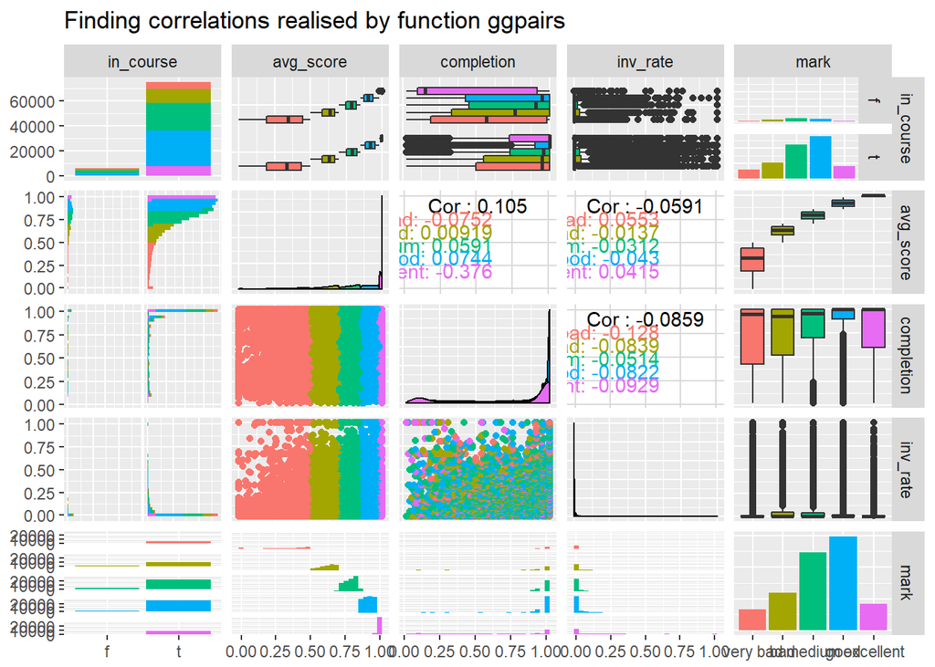

# Data analysis

#### Unit

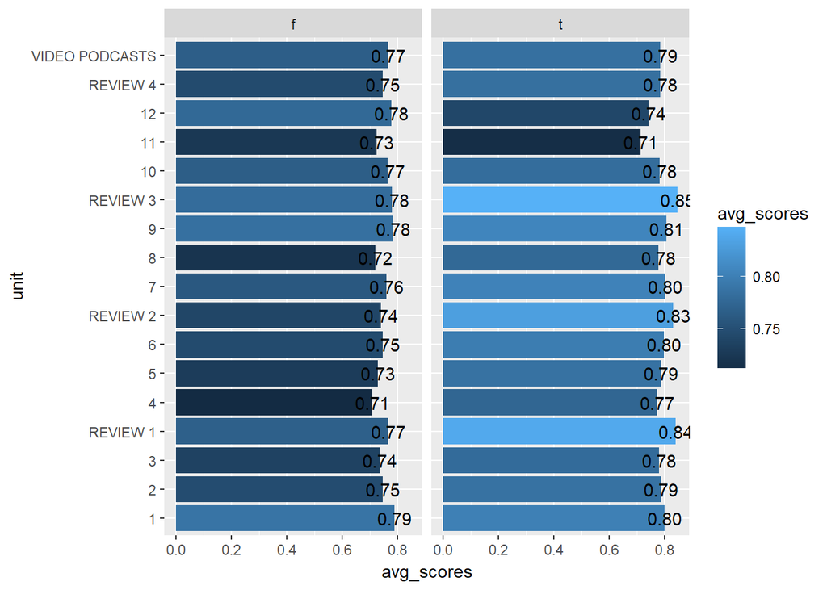

#### Impact ‘completion’ coefficient on data

- The strongest positive correlation between completion and avg_score is proof that it is important to complete all tasks - with high value of completion parameter avg_score is growing. Learners should be more convinced to complete all tasks in higher percent, because it can improve chances to get bigger mark.

#### Impact ‘inv_rate’ coefficient on data

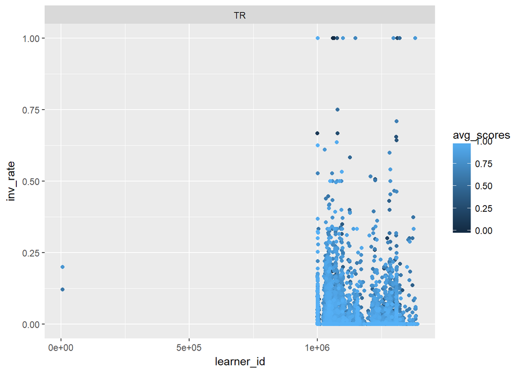